# 浅野ゼミナール 春合宿 2015

2015年度浅野ゼミ春合宿が5月9日〜10日の日程で茨城県神栖市で行われ、参加者は30名でした（拓大生28名、ゼミOB1名、立教大学の2年生1名）。春合宿の目的は学年の垣根を超えて親睦を深めることです。合宿が終わる頃には学年の垣根を越えて楽しそうに会話をする場面が見られました。

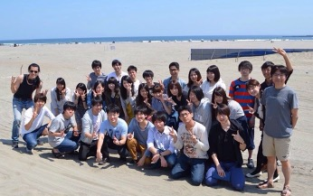

波崎海水浴場にて記念撮影

行きのバスの中では幹事が映画『ベイマックス』を用意してくれていて、時間を持て余すことなくホテルジャーニーロードへ到着しました。その後は部屋割りや自己紹介をして、夕食までの時間を買い出しや近くの海へ出かけたりと各々フリータイムを過ごしてしました。

夕食のバーベキューでは、お肉の他に焼きそばやソーセージなどがあり大変美味しかったです。食事の後は各自入浴を済ませ、オール飲み会とビンゴ大会が行われました。ビンゴ大会では幹事のジョークを交えた円滑な進行により大いに盛り上がりました。景品の中には浅野先生とのデート券などユニークなものもあり、参加者全員が大変楽しい時間を過ごしました。

[figure not shown]

ビンゴ大会での景品

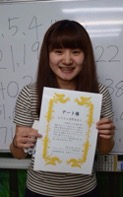

ビンゴ大会での景品

オール飲み会では普段接点のない２年生と交流を深め、有意義な時間を過ごしました。飲み会では、恋愛系のトークテーマが書かれたトランプを用いた暴露話に花が咲き、笑い声が部屋中いっぱいに広がっていました。

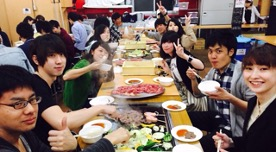

夕食はBBQ

翌日は朝食後、集合写真を撮影するために近くの砂浜へ皆で出かけました。空には青空が広がり、心地良い海風が吹き、快適な時間を過ごせました。撮影終了後、バスで帰路につきました。  
（文責：政経学部法律政治学科 中山郁弥）

### 参加学生の感想

#### 政経学部 経済学科 荒川萌音 ３年

初めは不安や緊張がありましたが、合宿を通して今まで見られなかった先輩、同輩、後輩の一面を見ることができ、学年を超えて親睦を深めることができたのではないかと思います。ビンゴ大会では司会のおもしろい進行もありとても楽しかったです。もらった景品で遊ぶこともできコミュニケーションをとる手助けになっていたと思います。先生から普段聞くことがないようなお話を聞くことができたことも印象的です。幹事の皆さんのおかげで有意義な２日間を過ごすことができました。

#### 政経学部 経済学科 2年 吉田陽一郎

合宿には一緒に授業をうけている２年生以外にも、普段の学校生活であまり会う機会がない3、4年生やOBの方が参加しました。私は数人の先輩としか面識がなかったので、うまくやっていけるか多少不安があったのですが、そんな不安は最初の自己紹介や先輩方の話を聞いたりしている内に払拭されていきました。 今回の春合宿で、先輩方とコミュニケーションを取れ交流できたことに加え、２年生同士でもお互いに知らなかった性格の一面が次々と発見でき、さらに仲を深めることができました。 全体を通して非常に有意義な合宿でしたので、参加できて本当に良かったです。